# d01evetrd

1.Курс UNetLab. Введение  
2.Курс UNetLab. Установка  
3.Курс UNetLab. Dynamips  
4.UNetLab. Telnet, VNC, Wireshark  
5.UNetLab. Создание сетевой топологии  
6.UNetLab. Компьютер в сетевой топологии - VPCS  
7.UNetLab. Компьютер в сетевой топологии - VMware  
8.UNetLab. Компьютер в сетевой топологии - QEMU  
9.UNetLab. Компьютер в сетевой топологии - Docker  
10.UNetLab. Cisco vIOS  
11.UNetLab. Cisco ASA

#### EVE - The Emulated Virtual Environment for Network

#### 1.Курс UNetLab. Введение

##### UNetLab - эмулятор сетевых устройств различных вендоров, т.е. не только Cisco UNetLab vs GNS3

| 1 | Для управления используется web-интерфейс. Не требуется установка каких либо клиентов. | Необходима установка клиента. Т.е. самой программы GNS3 |
| --- | --- | --- |
| 2 | Не зависит от используемой операционной системы. Т.е. одинаково работает как под Linux, так и под Windows. | Для каждой операционной системы - свой дистрибутив, со своим персональным набором багов. |
| 3 | Нет ограничений по оперативной памяти при использовании QEMU. | Ограничение QEMU в 2Гб оперативной памяти. |
| 4 | Нет ограничений по сетевым подключениям для QEMU. | QEMU ограничен 16-ю сетевыми подключениями |
| 5 | Мультиюзерная платформа. | Для одного пользователя. |
| 6 | UNetLab это яркий пример решений “Все в одном”. | В GNS3 есть необходимость в использовании VirtualBox или VMware Workstation для запуска не Cisco устройств. |

#### Составляющие UNetLab:

##### 1)Dynamips:

```
c7200-adventerprisek9-mz.152-4.S6 (supported cards: PA-FE-TX, PA-4E, PA-8E)
c3725-adventerprisek9-mz.124-15.T14 (supported cards: NM-1FE-TX, NM-16ESW)
c1710-bk9no3r2sy-mz.124-23
И другие
```

##### 2)IOL

```
L2-ADVENTERPRISE-M-15.1-20131216.bin
L2-ADVENTERPRISE-M-15.1-20140814.bin
L2-IPBASEK9-M-15.1-20130726.bin
L3-ADVENTERPRISEK9-M-15.4-1T.bin
L3-ADVENTERPRISEK9-M-15.4-2T.bin
L3-ADVIPSERVICES-M-15.1-2.9S.bin
И другие
```

##### 3)QEMU

```
Cisco ASA 8.0.2 (Singe and Multi Context)
Cisco ASA 8.4.2 (Support Multi Context)
Cisco ASA 9.1.15 (Support Multi Context)
Cisco ASAv (ver 9.3.2.200; 9.4.1; 9.5.1)
Cisco ACS (ver 5.7)
Cisco CDA (ver 1.0.0.011)
Cisco IPS - cips (ver 7.0-8)
Cisco ISE (ver 1.2)
Cisco vWAAS (ver 5.5.3)
Cisco WSA virtual appliance - coeus (ver 8-6-0-025-S000V)
Cisco CSR - csr1000v (ver 9.03.13.01.S.154-3.S1; 9.03.14.01.S.155-1.S1-std)
Cisco NX-OSv - titanium (ver 7.1.0.ZD.363; 7.2.0.ZD.0.120)
Cisco vIOS - vios-adventerprisek9 (ver 15.4.3M L3; 15.5.2 L3)
Cisco vIOS L2 - viosl2-adventerprisek9 (ver 15.2.411)
Cisco vNAM (ver 6.2.1)
Cisco Sourcefire - sourcefire (ver 5.4.0.763)
Cisco Wireless controller - vwlc (ver K9-8-0-100-0)
Cisco XRv - xrv-k9 (ver 5.2.2 - 5.3.2)
A10 Networks vThunder Virtual Appliance - a10-vthunder (ver 2.7.1-P3-b76)
Alcatel 7750 virtual service router - timos (ver 12.0.R6)
Arista networks switches (ver 4.14.2F; 4.14.5F; 4.15.0F)
Aruba Networks security - clearpass (ver 6.4.0.66263)
Brocade Virtual ADX - brocadevadx (ver 03.1.01)
Citrix Netscaler VPX virtual - nsvpx (ver 10.5.54.9008)
Checkpoint Firewall - cpsg (ver R77-20)
Cumulus VX
Extreme Networks virtual - extremexos (ver 15.3.2)
F5 BIG-IP LM - bigip (ver 11.6.0)
Fortinet virtual FW - fortinet (ver 5.2.2; 5.2.3_build670)
HP virtual router - hpvsr (ver 7.1.049P1; 7.10.R0204P01)
Juniper Networks M series router - olive (ver 12.3R8.7)
Juniper Networks vMX router - vmx (ver 14.1R1.10-domestic; 14.1R4.8-domestic)
Juniper Networks vSRX FW - vsrx (ver 12.1X46-D25.7-domestic)
Mikrotik (ver 6.30.2)
Ostinato Traffic Generator
Palo Alto virtual Firewall - paloalto (ver 6.1.0)
S-Terra Firewall
VyOS - vyos (ver vyos-1.1.6-amd64)
MS Windows
Various liveCD Linux images (eg. tinycore, damnsmalllinux, slax)
```

#### 2.Курс UNetLab. Установка

```
Существует 3 способа установки UNetLab:
1. Установка в VMware Workstation
2. Установка в VMware ESXi
3. Установка на компьютер
- Процессор должен поддерживать аппаратную
виртуализацию!
- Опция должна быть включена в BIOS!
```

#### 3.Курс UNetLab. Dynamips

```
Перед началом нам нужны:
1. Putty
2. WinSCP
3. Образы
```

64-howto-add-dynamips-images-cisco-ios

| EVE Image Name | Downloaded Filename | Version | vRAM | Idle PC |
| --- | --- | --- | --- | --- |
| c1710-bk9no3r2sy-mz.124-23.image | c1710-bk9no3r2sy-mz.124-23.bin | C1710-BK9NO3R2SY-M 12.4(23) | 96 | 0x80369ac4 |
| c3725-adventerprisek9-mz.124-15.T14.image | c3725-adventerprisek9-mz.124-15.T14.bin | C3725-ADVENTERPRISEK9-M 12.4(15)T14 | 256 | 0x60c08728 |
| c7200-adventerprisek9-mz.152-4.S2.image | c7200-adventerprisek9-mz.152-4.S2.bin | C7200-ADVENTERPRISEK9-M 15.2(4)S2 | 512 | 0x60630d5c |
| c7200-adventerprisek9-mz.152-4.S6.image | c7200-adventerprisek9-mz.152-4.S6.bin | C7200-ADVENTERPRISEK9-M 15.2(4)S6 | 512 | 0x62f224ac |

```
Папки для образов /opt/unetlab/addons (dynamips, iol и qemu)
Алгоритм для добавления образов:
1. Выбираем домашнюю папку для образа
2. Закидываем образ и распаковываем в image
3. /opt/unetlab/wrappers/unl_wrapper -a fixpermissions
```

#### 4.UNetLab. Telnet, VNC, Wireshark

```
Способы подключения к устройствам:
1. Telnet
2. VNC
Telnet клиенты:
1. Встроенный
2. Putty
3. SecureCRT
VNC Client - для подключения к устройствам без консоли
```

[Windows integration pack](https://www.eve-ng.net/downloads/windows-client-side-pack)

#### 5.UNetLab. Создание сетевой топологии

```
Типы соединений в UNL:
1. bridge
2. ovs
3. pnet (pnet0 -pnet9)
Алгоритм создания сети:
1. Нарисуйте схему на бумаге
2. Посчитайте кол-во внутренних и внешних соединений
3. Добавьте устройства
4. Добавьте сети
5. Редактируем подключения
```

[output not shown]

#### 6.UNetLab. Компьютер в сетевой топологии - VPCS

```
Способы использования компьютеров в UNL:
1. VPCS
2. VMware Workstation
3. Свой компьютер или реальные компьютеры из сети
4. QEMU
5. Docker
Обновитесь до версии 1.0.0-8
1. apt-get update
2. apt-get install unetlab
```

#### 7.UNetLab. Компьютер в сетевой топологии - VMware

```
Способы использования компьютеров в UNL:
1. VPCS
2. VMware Workstation
3. Свой компьютер или реальные компьютеры из сети
4. QEMU
5. Docker
Алгоритм добавления виртуальной машины
1. Создать виртуальную машину (Windows или Linux)
2. Определить VMnet для виртуальной машины
3. Добавить сетевой адаптер в UNetLab и определить его в тот же VMnet
```

#### 8.UNetLab. Компьютер в сетевой топологии - QEMU

```
Способы использования компьютеров в UNL:
1. VPCS
2. VMware Workstation
3. Свой компьютер или реальные компьютеры из сети
4. QEMU
5. Docker
Плюсы использования QEMU
1. Вся схема внутри UNetLab
2. Одну виртуальную машину можно использовать в схеме множество раз
Минусы использования QEMU
Сложная и запутанная настройка
Возможны два варианта использования QEMU
1. Для запуска Live дистрибутивов
2. Для запуска установленных операционных систем
```

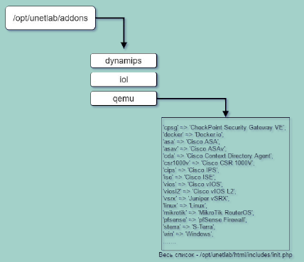

/opt/unetlab/html/includes/init.php

```
Алгоритм создания виртуальной машины qemu
1. В папке /opt/unetlab/addons/qemu создаем папку согласно файлу /opt/unetlab/html/includes/init.php
(пример: win-xp, linux-kali)
2. Закидываем в эту папку образ и переименовываем его в cdrom.iso (для live дистрибутивов на этом
настройка закончена)
3. Создаем жесткий диск командой /opt/qemu-2.0.2/bin/qemu-img create -f qcow2 hda.qcow2 3000M
4. Задаем права командой /opt/unetlab/wrappers/unl_wrapper -a fixpermissions
5. Стартуем и сразу стопим ноду
6. Копируем жесткий диск (hda.qcow2) в соответствующую папку /opt/unetlab/tmp
7. Производим установку
8. По завершению копируем жесткий диск из /opt/unetlab/tmp обратно в
/opt/unetlab/addons/qemu/ваша_папка
9. Зачищаем /opt/unetlab/tmp
10. Задаем права /opt/unetlab/wrappers/unl_wrapper -a fixpermissions
```

#### 9.UNetLab. Компьютер в сетевой топологии - Docker

```
Способы использования компьютеров в UNL:
1. VPCS
2. VMware Workstation
3. Свой компьютер или реальные компьютеры из сети
4. QEMU
5. Docker
```

1) Полная (аппаратная) виртуализация

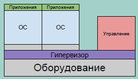

2) Виртуализация уровня ОС

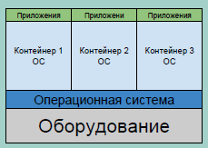

3) Виртуализация приложений

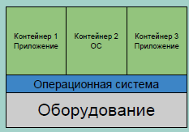

[350+ полезных ресурсов, книг и инструментов для работы с Docker](https://habr.com/ru/company/1cloud/blog/275015/)  
BusyBox

#### 10.UNetLab. Cisco vIOS

Cisco VIRL - эмуляция IOSv, IOS XRv, NX-OSv, CSR1000 и ASAv  
(all-in-one-VM-1.2.0-173.ova)  
(all-in-one-VM-1.3.0-181.ova)  
**vIOS L2 (коммутатор)**

- Layer-2 forwarding
- Switchport
- 802.1q trunk, 802.1q vlans
- Spanning Tree
- Port-Channel (Pagp and Lacp)
- 802.1x passthrough
- Port-ACLs
- Dynamic Arp Inspection
- DHCP Snooping
- IP device tracking
- Switched Virtual Interfaces
- Layer-3 forwarding over SVIs
- Routing protocols Чего НЕ умеет данный коммутатор:
- Зеркалирование трафика (SPAN)
- Private Vlan
- L3 Port-Chennel
- QOS  
  **vIOS (маршрутизатор)**
- Стандартный набор функций

##### Найти данные образы можно в интернете используя такие запросы как:

“iosv-l2 download”, “iosv-l3 download”

##### Алгоритм добавления образов:

1. В папке /opt/unetlab/addons/qemu создаем папки согласно файлу /opt/unetlab/html/includes/init.php (пример: vios-l3-15.4, viosl2-15.0)
2. Закидываем в соответствующие папки образы и переконвертируем их в формат qemu. Пример: Для vIOS L2 - /opt/qemu/bin/qemu-img convert -f vmdk -O qcow2 vIOS-L2.vmdk virtioa.qcow2 Для vIOS L3 - /opt/qemu/bin/qemu-img convert -f vmdk -O qcow2 vIOS-L3.vmdk virtioa.qcow2
3. Задаем права командой /opt/unetlab/wrappers/unl_wrapper -a fixpermissions
4. При добавлении устройств выставляйте 384 Мб оперативной памяти.
5. Для коммутатора максимальное количество портов - 16.

#### 11.UNetLab. Cisco ASA

##### Cisco ASA - самый известный межсетевой экран (16-й урок Курса молодого бойца)

##### В UNetLab доступно два вида Cisco ASA:

**1) Cisco ASA 8.0.2, 8.4.2, 9.1.15 (Support Multi Context)**  
Для поиска образов использовать следующие запросы в google: “ASA842-disk1.vmdk” и “ASA-9.15-disk1.vmdk”  
Системные требования: 512-768 Mb RAM и 100% загрузка ядра.  
При добавлении в папке /opt/unetlab/addons/qemu создается папка asa-... (asa-8.4 или asa-9.1)  
**2) Cisco ASAv (ver 9.3.2.200; 9.4.1; 9.5.1)**  
Для поиска образов использовать следующие запросы в google: “asav952-204.qcow2” или “asav941-200.qcow2”  
Системные требования: 1024-2048 Mb RAM и незначительная загрузка ядра.  
При добавлении в папке /opt/unetlab/addons/qemu создается папка asav-... (asav-9.4 или asav-9.5)  
*Алгоритм добавления образов:*

1. В папке `/opt/unetlab/addons/qemu` создаем папки согласно файлу `/opt/unetlab/html/includes/init.php` (пример: asa-8.4, asa-9.1,  
   asav-9.4 или asav-9.5)
2. Закидываем в соответствующие папки образы и переконвертируем их в формат qemu. Пример:  
   Для ASA - `/opt/qemu/bin/qemu-img convert -f vmdk -O qcow2 ASA842-disk1.vmdk hda.qcow2`  
   Для ASAv - достаточно переименовать образ в `virtioa.qcow2`
3. Задаем права командой `/opt/unetlab/wrappers/unl_wrapper -a fixpermissions`

##### 1.Курс UNetLab. Введение

##### 2.Курс UNetLab. Установка

##### 3.Курс UNetLab. Dynamips

##### 4.UNetLab. Telnet, VNC, Wireshark

##### 5.UNetLab. Создание сетевой топологии

##### 6.UNetLab. Компьютер в сетевой топологии - VPCS

##### 7.UNetLab. Компьютер в сетевой топологии - VMware

##### 8.UNetLab. Компьютер в сетевой топологии - QEMU

##### 9.UNetLab. Компьютер в сетевой топологии - Docker

##### 10.UNetLab. Cisco vIOS

##### 11.UNetLab. Cisco ASA